# Pitcher card

# Eli Morgan

RHP · KC

2026 · 16 G (0 GS) · 339 pitches · Apr 04 – Jul 18, 2026

Independent portfolio sample by Devin Jenkinson, not affiliated with any club. Every number is computed from public Statcast data.

Three big takeaways

1Watch

The changeup is his most-used two-strike pitch.

43% of two-strike pitches · 23 two-strike swings so far

No pitch has 50+ two-strike swings yet, so this card does not name a put-away pitch by miss rate.

2Avoid

Limit the 4-seam fastball. It is his most damaging pitch.

xRV/100 -1.52 shrunk (raw -4.39) · .469 xwOBAcon · 126 pitches

When behind in the count he throws it 62% of the time; the changeup grades +0.24 there instead.

3Watch

Build the 4-seam fastball sample before setting a height plan.

42 swings up · 6 swings down

Rates under 50 swings are not quoted on this card.

Charts

### Movement

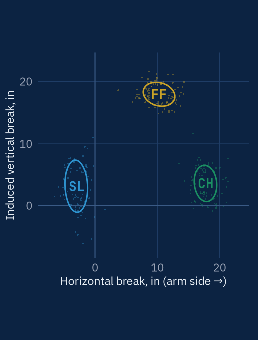

n = 339 pitches. Ellipses hold about 68% of each type; codes sit at the averages.

### Location by count

He throws 48% of pitches in the zone when behind and 35% when ahead.

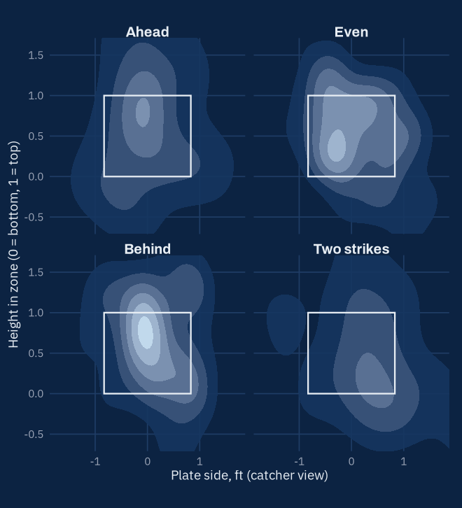

n = 339. Ahead 49 · even 132 · behind 63 · two strikes 95 pitches. Box = rule-book zone.

### Put-away

The CH is 43% of two-strike pitches vs 33% overall.

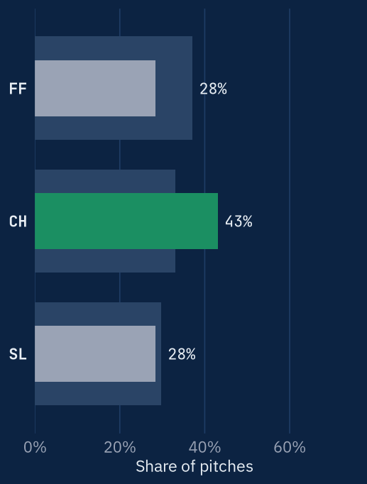

Two-strike n: CH 41, FF 27, SL 27. Grey bars = overall usage; wh = whiffs per swing (shown with 50+ swings).

### Arsenal

| Pitch | # | Use | Velo | IVB | HB | VAA | Whiff | Chase | xwOBAcon | xRV/100 | Stuff+ |
| --- | --- | --- | --- | --- | --- | --- | --- | --- | --- | --- | --- |
| 4-Seam (FF) | 126 | 37% | 91.2 | 18.0 | +10.3 | -4.2 | 18% | 31% | .469 | -1.52 | 82 |
| Changeup (CH) | 112 | 33% | 77.0 | 3.6 | +17.8 | -8.2 | 18% | 39% | .337 | +0.24 | 107 |
| Slider (SL) | 101 | 30% | 85.4 | 3.1 | -2.9 | -7.3 | 38% | 32% | .607 | -0.21 | 96 |

IVB / HB in inches (HB + = arm side). VAA in degrees at the front of the plate. xRV/100 = expected run value per 100 pitches, pitcher’s view, shrunk with a 250-pitch prior. Stuff+ = this project’s shape-only model (100 = MLB average, 10 = 1 SD).

### Vs. batter hand

| Pitch | LHH # | Use | Whiff | xwOBAcon | RHH # | Use | Whiff | xwOBAcon |
| --- | --- | --- | --- | --- | --- | --- | --- | --- |
| FF | 69 | 42% | – | .585 | 57 | 33% | – | .373 |
| CH | 69 | 42% | – | .428 | 43 | 25% | – | .196 |
| SL | 28 | 17% | – | .347 | 73 | 42% | – | .458 |

Use = share of pitches to that side. Whiff = whiffs per swing, shown with 50+ swings.